# Getting Started with ResistanceGA

Bill Peterman

29 July 2021

# Background

`ResistanceGA` is an R package built around the use of a genetic algorithm optimization approach for assigning resistance values to landscape features. The genetic algorithm used comes from the `GA` package. There are numerous options and settings available to adjust within the genetic algorithm itself. Most of these can be adjusted or used within `ResistanceGA`, but most have defaults that do not need to be adjusted. Many of the defaults I’ve set are the result of trial and error with toy data sets, but they seem to have held up through the analysis of many different data sets. Having said this, you may want to explore how adjusting some of the `GA` settings affects your results. This vignette is largely meant to replace the original (now very dated) vignette, but I have not removed this older vignette from the package for posterity and continuity.

If you haven’t already done so, install `ResistanceGA`.

```r
devtools::install_github("wpeterman/ResistanceGA", build_vignettes = TRUE)
```

If this fails, you may want to try installing the `tinytex` R package and trying again, or else turn off the building of vignettes.

Let’s take a quick look at some these data objects.

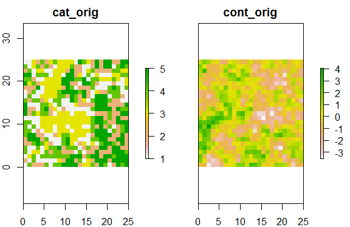

```r
library(ResistanceGA)

plot(raster_orig)
```

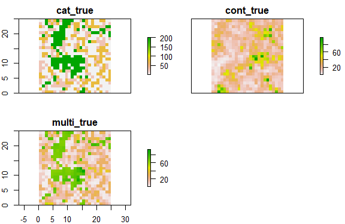

```r
plot(raster_true)
```

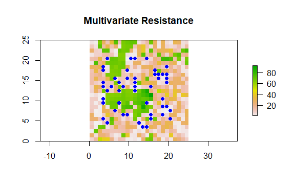

```r
plot(raster_true$multi_true, main = 'Multivariate Resistance')
plot(sample_pops$sample_multi, add = T, pch = 19, col = 'blue')
```

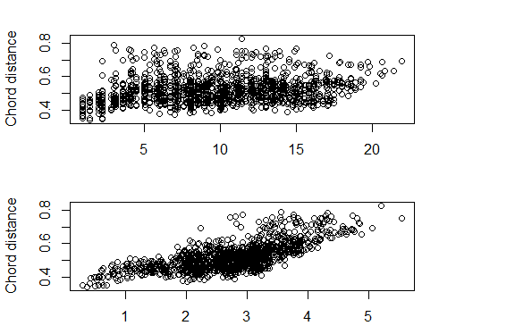

```r
par(mfrow = c(2,1))
plot(lower(Dc_list$Dc_multi) ~
       c(dist(sample_pops$sample_multi@coords)),
     xlab = 'Euclidean distance', ylab = 'Chord distance')

plot(lower(Dc_list$Dc_multi) ~
       lower(resist_list$resist_multi),
     xlab = 'Resistance distance', ylab = 'Chord distance')
```

```r
par(mfrow = c(1,1))
```

# Basic Functions

## Preparation Functions

Prior to running `ResistanceGA`, two preparation functions will always need to be run. These functions take your data, specified inputs, and run settings and package them up for optimization of your resistance surface(s) using the `GA` package.

## GA.prep

With this function, you specify all the details and options of how you want to conduct optimization with the genetic algorithm. There are a LOT of settings! **However, only two things must be specified: `ASCII.dir` and `Results.dir`.** The `ASCII.dir` can be a raster object, a raster stack, or the path to a directory containing `.asc` raster files. The `Results.dir` is where you want files generated during the analysis to be written.

```r
GA.prep(ASCII.dir,            # REQUIRED
        Results.dir = NULL,   # REQUIRED
        min.cat = NULL,
        max.cat = 2500,
        max.cont = 2500,
        min.scale = NULL,
        max.scale = NULL,
        cont.shape = NULL,
        select.trans = 'M',
        method = "LL",
        scale = FALSE,
        scale.surfaces = NULL,
        k.value = 2,
        pop.mult = 15,
        percent.elite = 0.05,
        type = "real-valued",
        pcrossover = 0.85,
        pmutation = 0.125,
        maxiter = 1000,
        run = NULL,
        keepBest = TRUE,
        population = gaControl(type)$population,
        selection = gaControl(type)$selection,
        crossover = "gareal_blxCrossover",
        mutation = gaControl(type)$mutation,
        pop.size = NULL,
        parallel = FALSE,
        gaisl = FALSE,
        island.pop = 20,
        numIslands = NULL,
        migrationRate = NULL,
        migrationInterval = NULL,
        optim = FALSE,
        optim.method = "L-BFGS-B",
        poptim = 0.0,
        pressel = 1.00,
        control = list(fnscale = -1, maxit = 100),
        hessian = FALSE,
        opt.digits = NULL,
        seed = NULL,
        monitor = TRUE,
        quiet = FALSE)
```

### GA parameters you may want to adjust

While all that you need to specify to set up the genetic algorithm is your raster information and a directory for results, there are a few other parameters that one may want to adjust.  
1) `select.trans`: By default only Monomolecular family transformations are explored. If you want to specify more nonlinear, Ricker family transformations, you can change the this parameter to ‘A’ for all transformations, or ‘R’ for only Ricker. It is also possible to specify specific transformations for certain layers (see the GA.prep documentation)  
2) `shape.min` & `shape.max`: You may want to limit/constrain the amount of non-linearity in the explored transformations. You can specify lower and upper limits to the shape parameter here.  
3) `pop.size`: How many individuals do you want to create each iteration? A larger population gives a greater ‘gene pool’ to select from, but comes at the cost of additional computational time.  
4) `maxiter`: When initially exploring/setting up a run, you may only want to conduct one or two iterations to confirm that everything is working as expected.  
5) `run`: How many iterations need to pass before the genetic algorithm stops? By default, this is 25, but you may want to increase or decrease this depending upon your data.

## gdist.prep

Running this function is necessary prior to using `ResistanceGA` with `gdistance`. **The minimum information that needs to be specified for conducting an analysis is `n.Pops`, `response`, and `samples`.**

```r
gdist.prep(n.Pops,           # REQUIRED
           response = NULL,  # REQUIRED
           samples,          # REQUIRED
           covariates = NULL,
           formula = NULL,
           transitionFunction = function(x)  1 / mean(x),
           directions = 8,
           longlat = FALSE,
           method = 'commuteDistance',
           min.max_dist = NULL,
           keep = NULL)
```

## jl.prep

If using CIRCUITSCAPE, [programmed in the Julia language](https://github.com/Circuitscape/Circuitscape.jl), this preparation function needs to be run. This approach is the fastest and most flexible approach for landscape resistance optimization with `ResistanceGA`. It does require that [Julia >= v1.4.0](https://julialang.org/) and the CIRCUITSCAPE package are installed on your computer. See the `Julia_Guide` for further details on getting this set up. **The minimum information that needs to be specified for conducting an analysis is `n.Pops`, `response`, `CS_Point.File`, and `JULIA_HOME`.**

```r
jl.prep(n.Pops,             # REQUIRED
        response = NULL,    # REQUIRED
        CS_Point.File,      # REQUIRED
        covariates = NULL,
        formula = NULL,
        JULIA_HOME = NULL,  # REQUIRED
        Neighbor.Connect = 8,
        pairs_to_include = NULL,
        pop2ind = NULL,
        nb = NULL,
        parallel = FALSE,
        cores = NULL,
        cholmod = TRUE,
        precision = FALSE,
        run_test = TRUE,
        write.files = NULL,
        write.criteria = NULL,
        silent = TRUE,
        Julia_link = 'JuliaCall',
        scratch = NULL,
        rm.files = TRUE)
```